# Ornek Teorisi

```python
import numpy as np
```

```python
population=np.random.randint(0,80,10000) #age from 0 to 80 random 10000 people
```

```python
population[0:10] #Top 10 randomly selected.
```

```
array([45, 24, 21, 54, 31, 30, 72, 39, 71, 65])
```

```python
#sample taking
np.random.seed(115) #her tekrar edildiğinde aynı yapıya göre örneklem çeker.
orneklem=np.random.choice(a=population,size=100)#populasyon içinden rastgele 100 örneklem çek.
orneklem[0:10]
```

```
array([42, 54,  3, 10,  2, 49, 32,  1, 71,  5])
```

```python
orneklem.mean()
```

```
34.81
```

```python
population.mean()
```

```
39.6165
```

```python
#orneklem dağılımı
np.random.seed(10)
orneklem1=np.random.choice(a=population,size=100)
orneklem2=np.random.choice(a=population,size=100)
orneklem3=np.random.choice(a=population,size=100)
orneklem4=np.random.choice(a=population,size=100)
orneklem5=np.random.choice(a=population,size=100)
orneklem6=np.random.choice(a=population,size=100)
orneklem7=np.random.choice(a=population,size=100)
orneklem8=np.random.choice(a=population,size=100)
orneklem9=np.random.choice(a=population,size=100)
orneklem10=np.random.choice(a=population,size=100)
#merkezi limit teoremi aracılığıyla ana kitle ortalamasına doğru gitmiş oluyoruz.
```

```python
(orneklem1.mean()+orneklem2.mean()+orneklem3.mean()+orneklem4.mean()+orneklem5.mean()+orneklem6.mean()+orneklem7.mean()+
orneklem8.mean()+orneklem9.mean()+orneklem10.mean())/10
```

```
40.343
```

```python
population.mean()
```

```
39.6165
```

```python
orneklem1.mean()
```

```
40.15
```

#### Descriptive statistic

covereiance:2 değişken arası ilişkinin değişkenlik ölçüsüdür. Ortalama etrafındaki dağılımın ölçüsü varyanstır.

### Corelation:

Korelasyon:değişken arasındaki ilişkiyi,ilişkinin anlamlı olup olmadığını, ilişkinin şiddetini ve yönünü ifade eden istatiksel terimdir.

#### Betimsel İstatistikler:

```python
import seaborn as sns
tips=sns.load_dataset("tips")
df=tips.copy()

df.head(15)
```

|  | total_bill | tip | sex | smoker | day | time | size |
| --- | --- | --- | --- | --- | --- | --- | --- |
| 0 | 16.99 | 1.01 | Female | No | Sun | Dinner | 2 |
| 1 | 10.34 | 1.66 | Male | No | Sun | Dinner | 3 |
| 2 | 21.01 | 3.50 | Male | No | Sun | Dinner | 3 |
| 3 | 23.68 | 3.31 | Male | No | Sun | Dinner | 2 |
| 4 | 24.59 | 3.61 | Female | No | Sun | Dinner | 4 |
| 5 | 25.29 | 4.71 | Male | No | Sun | Dinner | 4 |
| 6 | 8.77 | 2.00 | Male | No | Sun | Dinner | 2 |
| 7 | 26.88 | 3.12 | Male | No | Sun | Dinner | 4 |
| 8 | 15.04 | 1.96 | Male | No | Sun | Dinner | 2 |
| 9 | 14.78 | 3.23 | Male | No | Sun | Dinner | 2 |
| 10 | 10.27 | 1.71 | Male | No | Sun | Dinner | 2 |
| 11 | 35.26 | 5.00 | Female | No | Sun | Dinner | 4 |
| 12 | 15.42 | 1.57 | Male | No | Sun | Dinner | 2 |
| 13 | 18.43 | 3.00 | Male | No | Sun | Dinner | 4 |
| 14 | 14.83 | 3.02 | Female | No | Sun | Dinner | 2 |

```python
df.describe().T
```

|  | count | mean | std | min | 25% | 50% | 75% | max |
| --- | --- | --- | --- | --- | --- | --- | --- | --- |
| total_bill | 244.0 | 19.785943 | 8.902412 | 3.07 | 13.3475 | 17.795 | 24.1275 | 50.81 |
| tip | 244.0 | 2.998279 | 1.383638 | 1.00 | 2.0000 | 2.900 | 3.5625 | 10.00 |
| size | 244.0 | 2.569672 | 0.951100 | 1.00 | 2.0000 | 2.000 | 3.0000 | 6.00 |

```python
#!pip install researchpy
import researchpy as rp
```

```python
##Sayısal değişkenler için

rp.summary_cont(df[["total_bill","tip","size"]])
#sayısal değerlerin sayısını,ortalama değerleri ,standart hatası
#,standart sapması ve güven aralığını gösteren tablodur.
```

|  | Variable | N | Mean | SD | SE | 95% Conf. | Interval |
| --- | --- | --- | --- | --- | --- | --- | --- |
| 0 | total_bill | 244.0 | 19.785943 | 8.902412 | 0.569919 | 18.663332 | 20.908554 |
| 1 | tip | 244.0 | 2.998279 | 1.383638 | 0.088578 | 2.823799 | 3.172758 |
| 2 | size | 244.0 | 2.569672 | 0.951100 | 0.060888 | 2.449737 | 2.689608 |

```python
#Kategorik değişken için
rp.summary_cat(df[["sex","smoker","day","time"]])

#kategorik değişkenlerin sınıf frekansını verir,kaç adet olduğunu  ve yüzdeyi verir.
```

|  | Variable | Outcome | Count | Percent |
| --- | --- | --- | --- | --- |
| 0 | sex | Male | 157 | 64.34 |
| 1 |  | Female | 87 | 35.66 |
| 2 | smoker | No | 151 | 61.89 |
| 3 |  | Yes | 93 | 38.11 |
| 4 | day | Sat | 87 | 35.66 |
| 5 |  | Sun | 76 | 31.15 |
| 6 |  | Thur | 62 | 25.41 |
| 7 |  | Fri | 19 | 7.79 |
| 8 | time | Dinner | 176 | 72.13 |
| 9 |  | Lunch | 68 | 27.87 |

```python
df[["total_bill","tip","size"]].cov()
```

|  | total_bill | tip | size |
| --- | --- | --- | --- |
| total_bill | 79.252939 | 8.323502 | 5.065983 |
| tip | 8.323502 | 1.914455 | 0.643906 |
| size | 5.065983 | 0.643906 | 0.904591 |

```python
df[["total_bill","tip","size"]].corr()
```

|  | total_bill | tip | size |
| --- | --- | --- | --- |
| total_bill | 1.000000 | 0.675734 | 0.598315 |
| tip | 0.675734 | 1.000000 | 0.489299 |
| size | 0.598315 | 0.489299 | 1.000000 |

#### Güven aralığı :

Populasyon parametresinin tahmini değerini kapsayabilecek iki sayıdan oluşan bir aralık bulunmasıdır. Aynı zamanda ölçümün hassasiyetini gösteren bir terimdir.

Gerçekleşicek olan 100 denemeden 95 i ortalama bulunan aralıktadır. *1) n ,ortalama ve standart sapmayı bul.*2) Güven aralığına karar ver. *3) Z tablo değerini hesaple (CL=0,95 için z_tablo değeri 1.96 dır.)

Bu bilgilerle güven aralığını hesapla.

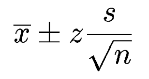

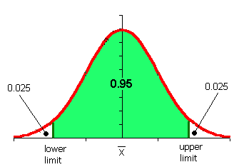

##### Ornek

- Problem Ceo fiyat belirleme konusunda bilimsel dayanak ve esneklik istiyor.
- Detaylar:

  Satıcı ,alıcı ve bir ürün var.

  Alıcılara ürüne ne kadar öderdiniz diye soruluyo.

  Optimum fiyat bilimsel ve esenk bulunmak isteniyor.

```python
#Alıcıların cevaplarını ortalamasını söyleyip güven aralığını alıyoruz.
fiyatlar=np.random.randint(10,110,1000)
fiyatlar.mean()
#Güven aralığı ile daha doğru model elde ederiz.
```

```
58.492
```

```python
import statsmodels.stats.api as sms
```

```python
sms.DescrStatsW(fiyatlar).tconfint_mean()
#Çıkarıcak olunan ürünün satın alınmak üzere ,
#Kullanıcıların ödemeyi göze aldığı ücretle %95 güvenle 56-60 arasındadır.
#kullanıcıların %95 ini kapsamış olabilir.
```

```
(56.67953887736034, 60.30446112263965)
```